# 1. ggplot2란?

- R의 데이터 시각화 패이지
- 엑셀, 파워포인트와는 다르게 함수를 입력하여 그래프를 그릴 수 있음

# 2. ggplot2의 핵심 - 레이어 추가

- ggplot2의 장점은 일관된 기초 문법을 가지고 있으며, 함수가 직관적이고, 그래픽 시스템의 완성도가 높음
- 그중 주목할 만한 장점은 레이어 추가 방식
- ggplot2 함수는 기본적으로 레이어를 추가하는 방식으로 그래프를 그려나감
- 레이어를 추가해 가면서 그래프를 꾸미고 정보를 더해 나갈 수 있음
- 그래프를 제거하거나 변형시키는 것도 레이어추가를 통해 할 수 있음

# 3. 레이어 추가를 통해 그래프 그려보기

```r
install.packages('ggplot2')
```

```r
library(ggplot2)
```

- R 내장 데이터인 pressure을 통해 좌표계를 그려줌

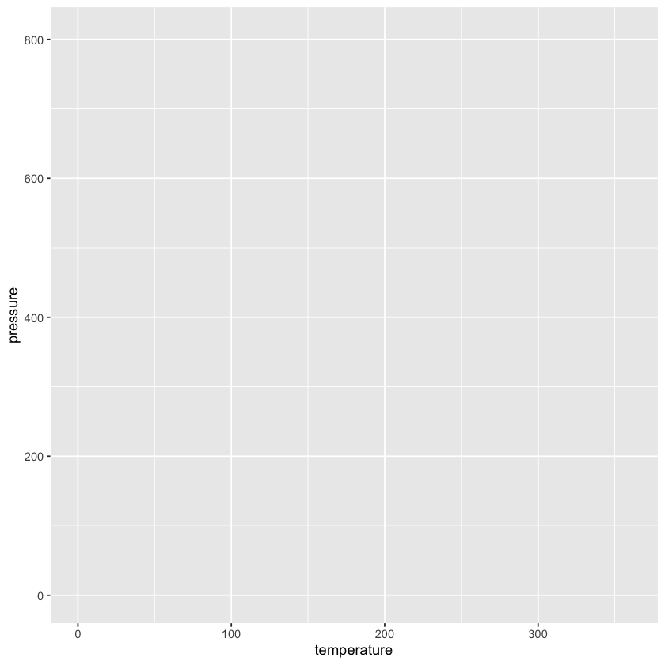

```r
ggplot(data=pressure, aes(x=temperature, y=pressure))
```

- +geom_point() + geom_line()을 통해 어떤 타입의 그래프를 그릴지를 설정할 수 있음
- 좌표계에 포인트와 라인 그래프가 추가된 것을 확인 할 수 있음

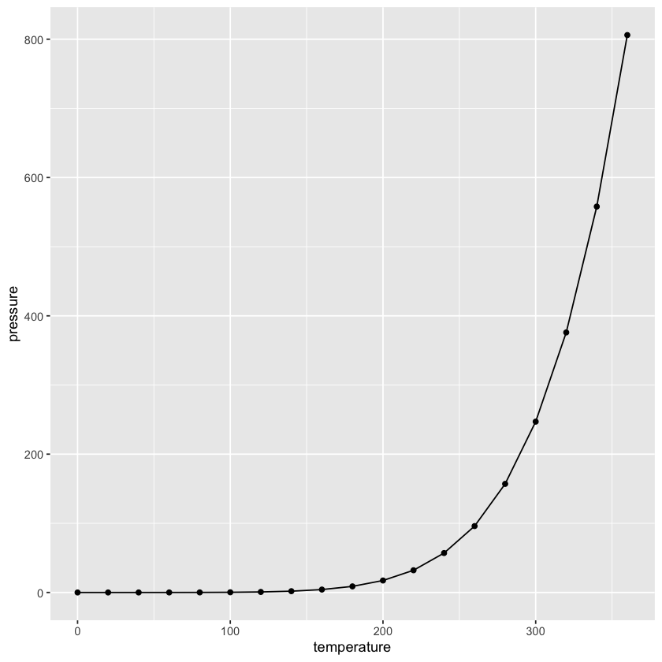

```r
ggplot(data=pressure, aes(x=temperature, y=pressure)) +
    geom_point() +
    geom_line()
```

- geom_point () 안에서 자유롭게 색과 사이즈 설정이 가능

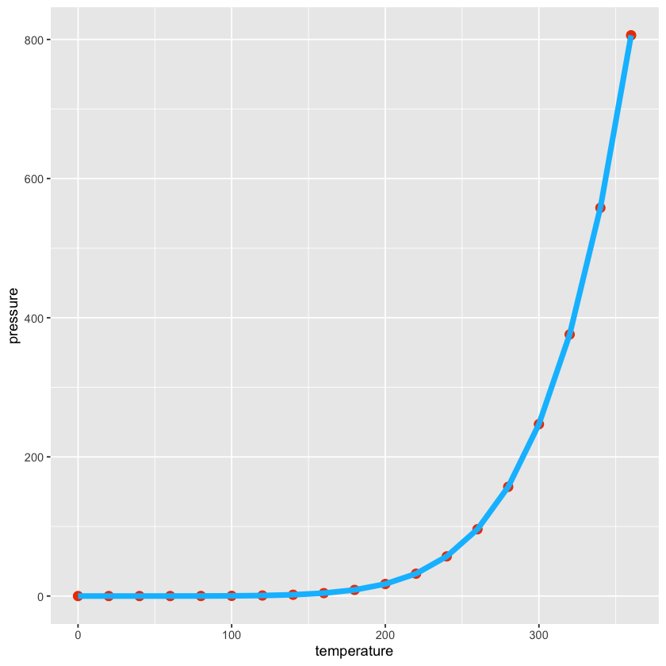

```r
ggplot(data=pressure, aes(x=temperature, y=pressure)) +
    geom_point(color='orangered2', size=3) +
    geom_line(color='deepskyblue', size=2)
```

- point를 가리지 않기 위해 함수에서 geom_point와 geom_line의 순서를 바꿔줌

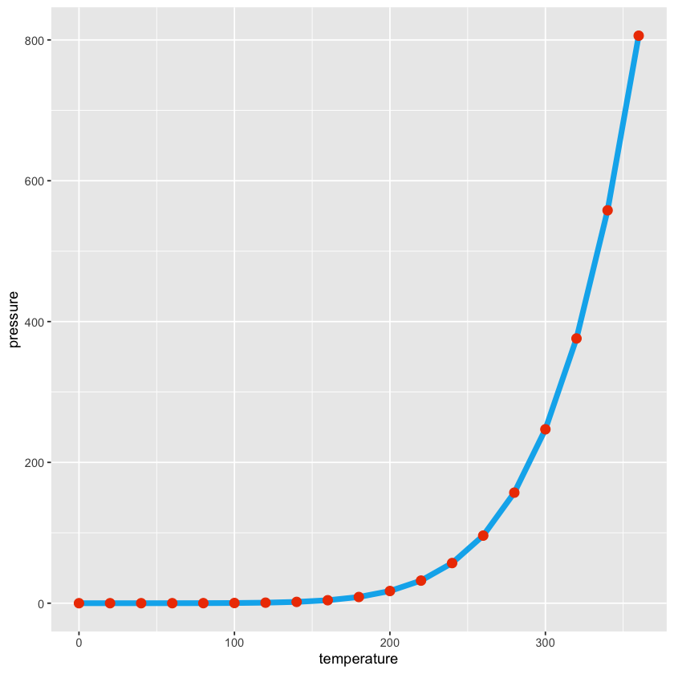

```r
ggplot(data=pressure, aes(x=temperature, y=pressure)) +
    geom_line(color='deepskyblue2', size=2) +
    geom_point(color='orangered2', size=3)
```

- ggtitle, xlab, ylab을 통해 그래프의 타이틀을 바꿔줌
- 테마 또한 theme_bw() 함수를 통해 바꿔 줌
- 그 외에도 theme_void(), theme_grey(), theme_classic() 등 여러가지 테마가 있으며 원하는 테마를 자유롭게 선택할 수 있음

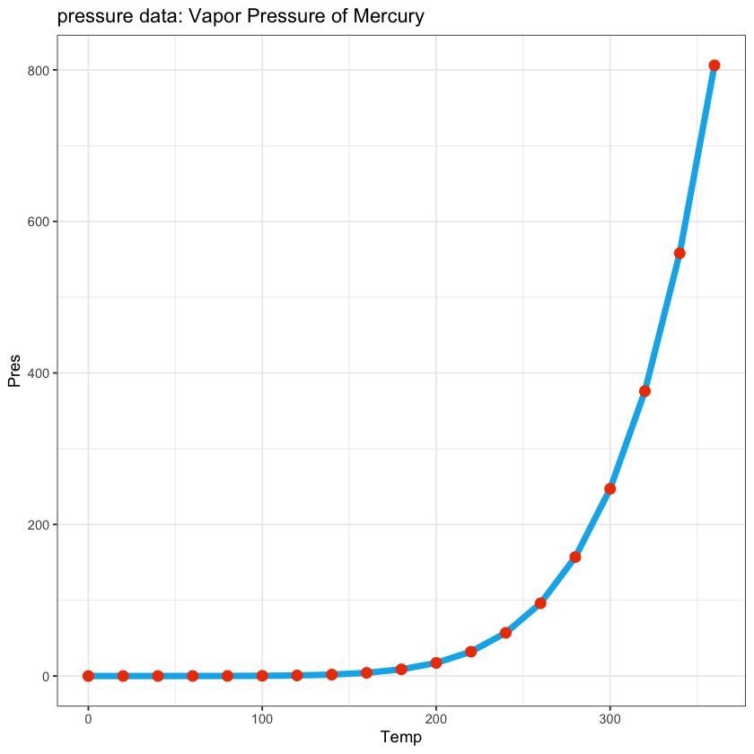

```r
ggplot(data=pressure, aes(x=temperature, y=pressure)) +
    geom_line(color='deepskyblue2', size=2) +
    geom_point(color='orangered2', size=3) +
    ggtitle('pressure data: Vapor Pressure of Mercury') +
    xlab('Temp') + ylab('Pres') + theme_bw()
```

- theme 함수를 이용해 그래프의 세부 사항인 텍스트의 앵글, 사이즈, 위치를 변경

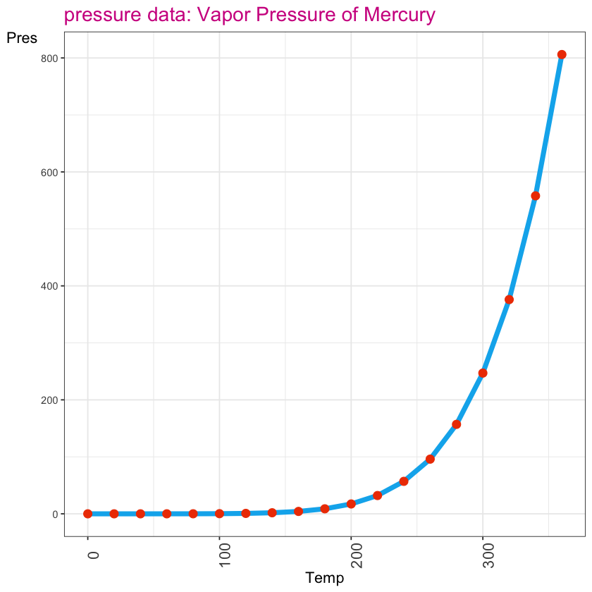

```r
ggplot(data=pressure, aes(x=temperature, y=pressure)) +
    geom_line(color='deepskyblue2', size=2) +
    geom_point(color='orangered2', size=3) +
    ggtitle('pressure data: Vapor Pressure of Mercury') +
    xlab('Temp') + ylab('Pres') + theme_bw() +
    theme(plot.title=element_text(size=17, color='violetred'),
         axis.title=element_text(size=13),
         axis.title.y=element_text(angle=0),
         axis.text.x=element_text(angle=90, size=13))
```